# hyptest

Daianne Starr

2023-05-10

## Intro

If you ever found the principles of statistical inference or hypothesis testing complicated, this pakage is for you. **hyptest** is based on the `infer package` and uses simulation-based approaches to calcualte test statistics and test hypothesis.

## Get started

Please copy and paste, and run this code below in your RStudio. It is an interactive interface that helps the user to shortlist the best function within the hyptest current version.

This code defines a function called **where_to_start()** that interacts with the user to suggest the appropriate statistical inference method based on their needs.

The function asks the user to choose one of three options: (A) Estimate a value, (B) Evaluate a relationship, or (C) Test a hypothesis.

Based on the user’s response, the function asks a series of questions to narrow down the appropriate statistical method for the user’s situation and provides a recommendation from the **hyptest** package for that method.

[output not shown]

## More examples

### Example 1

Let’s test another example of the **hyptest** package using a dataset that contains Divorce rate and margarine consumption data!

```r
library(tidyverse)
library(dslabs)

glimpse(divorce_margarine)
```

```
## Rows: 10
## Columns: 3
## $ divorce_rate_maine               <dbl> 5.0, 4.7, 4.6, 4.4, 4.3, 4.1, 4.2, 4.…
## $ margarine_consumption_per_capita <dbl> 8.2, 7.0, 6.5, 5.3, 5.2, 4.0, 4.6, 4.…
## $ year                             <int> 2000, 2001, 2002, 2003, 2004, 2005, 2…
```

I want to obtain the 95% confidence interval for the correlation between the divorce rate and margarine consumption and save the result as png.

```r
library(hyptest)

est_corr(divorce_margarine, margarine_consumption_per_capita, divorce_rate_maine, cil = 0.95, bin_num = 40, save_as = "png")
```

```
## [1] "The sample correlation is  0.99"
## [1] "The true population correlation is between 0.97 and 1.01 at 95% confidence interval"
```

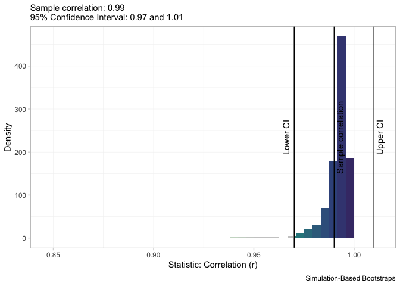

### Example 2

Examining the dataset about Italian olives, what is the proportion of olives produced in Southern Italy in this study?

```r
glimpse(olive)
```

```
## Rows: 572
## Columns: 10
## $ region      <fct> Southern Italy, Southern Italy, Southern Italy, Southern I…
## $ area        <fct> North-Apulia, North-Apulia, North-Apulia, North-Apulia, No…
## $ palmitic    <dbl> 10.75, 10.88, 9.11, 9.66, 10.51, 9.11, 9.22, 11.00, 10.82,…
## $ palmitoleic <dbl> 0.75, 0.73, 0.54, 0.57, 0.67, 0.49, 0.66, 0.61, 0.60, 0.55…
## $ stearic     <dbl> 2.26, 2.24, 2.46, 2.40, 2.59, 2.68, 2.64, 2.35, 2.39, 2.13…
## $ oleic       <dbl> 78.23, 77.09, 81.13, 79.52, 77.71, 79.24, 79.90, 77.28, 77…
## $ linoleic    <dbl> 6.72, 7.81, 5.49, 6.19, 6.72, 6.78, 6.18, 7.34, 7.09, 6.33…
## $ linolenic   <dbl> 0.36, 0.31, 0.31, 0.50, 0.50, 0.51, 0.49, 0.39, 0.46, 0.26…
## $ arachidic   <dbl> 0.60, 0.61, 0.63, 0.78, 0.80, 0.70, 0.56, 0.64, 0.83, 0.52…
## $ eicosenoic  <dbl> 0.29, 0.29, 0.29, 0.35, 0.46, 0.44, 0.29, 0.35, 0.33, 0.30…
```

I want to obtain the 99% confidence interval for the proportion of olives produced in Southern Italy and save the result as pdf.

```r
est_prop(olive, region, "Southern Italy", cil = 0.99, bin_num = 30, save_as = "pdf")
```

```
## [1] "The sample proportion is 0.56"
## [1] "The true population proportion is between 0.51 and 0.61 at 99% confidence interval"
```

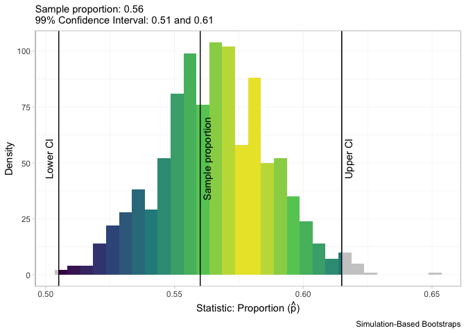

```r
library(palmerpenguins)
```